# IDS investigation worksheet

by The Git Gods: Kieran Lewis, Khushi Wadhwa, Caio Celano, Grace Tait & Nor Danish Raziq

2023-11-30

**Note:** You can use this file as you ‘working document’ where you can try out various investigation ideas and keep notes about your findings. How you use and structure this file is up to you. It is recommended that you keep notes about what you are investigating and what you find as this will make the process of creating your presentation and report easier. Please note that you *do not* need to submit this file as part of your group project.

```r
library(tidyverse)
library(ggplot2)
library(tidymodels)
# Add any other libraries here
```

We chose the mental health inpatient activity data. Our ideas are revolving around joining two or more datasets in order to find a relationship between several variables, e.g. how do different variables (age, diagnosis, hospital) affect the length of stay?

During our first workshop we had the idea of joining the data by diagnosis, since it will exclude any patients with missing diagnosis, and also provide the patients’ characteristics.

Initial ideas:

- Number of patients in each age range
  - Percentage of male and female in each age range
- Length of stay and diagnosis for each age range / sex
  - Would health beliefs impact length of stay/diagnosis?
  - Would area of admission impact length of stay/diagnosis?
- How has awareness of mental health evolved over time?
  - Frequency of stays
- Number of admissions during each year/time period
  - What external factors would effect this?
  - Percentage of male/females. Did numbers change over time? Did men become more accepting to health care?
  - Percentage of age ranges. Did numbers change over time?
- How has the treatment for mental health changed between 1997/98 and 2021/22
  - merge the relevant data sets to get a more complete view

  count of patients - y axis and then barchart, each bar is one year whole of scotland, either look at financial year or age group
  1. take only 2 financial years, look at the count of patients of each sex in each age range. then make box plot for lenght of stay. then look at diagnosis of each. one graph, x axis age group, y axis would be patient count and then make bar chart of two different colours in each bar represeting male and female.

```r
# Load your data
mental_health_inpatient_activity_age_sex <- read_csv("data/mental-health-inpatient-activity-age-sex.csv")
```

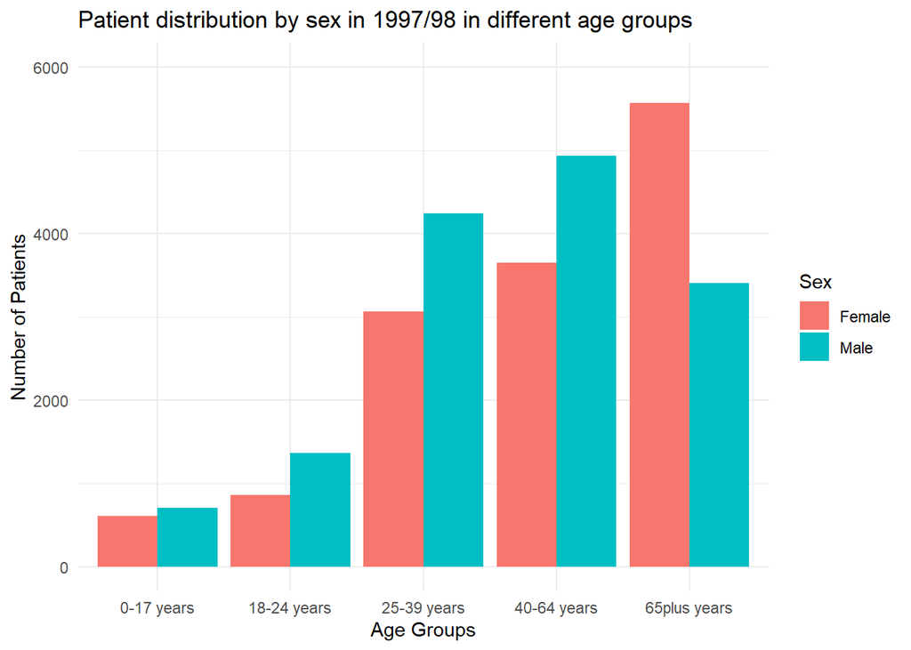

```r
y97_98<-filter(mental_health_inpatient_activity_age_sex,FinancialYear=="1997/98")
y21_22<-filter(mental_health_inpatient_activity_age_sex,FinancialYear=="2021/22")
plot1<-ggplot(y97_98,aes(fill=Sex,y=PatientsCount,x=AgeGroup))+geom_bar(position="dodge",stat="identity")+ labs(title = "Patient distribution by sex in 1997/98 in different age groups",
       x = "Age Groups",
       y = "Number of Patients")+theme_minimal()+ylim(0,6000)
plot2<-ggplot(y21_22,aes(fill=Sex,y=PatientsCount,x=AgeGroup))+geom_bar(position="dodge",stat="identity")+labs(title = "Patient distribution by sex in 2021/22 in different age groups",
       x = "Age Groups",
       y = "Number of Patients")+ylim(0,6000)+theme_minimal()
plot1
```

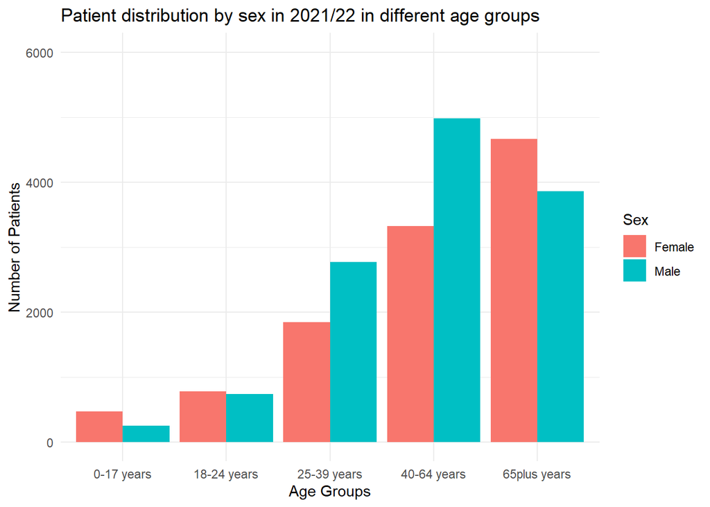

```r
plot2
```

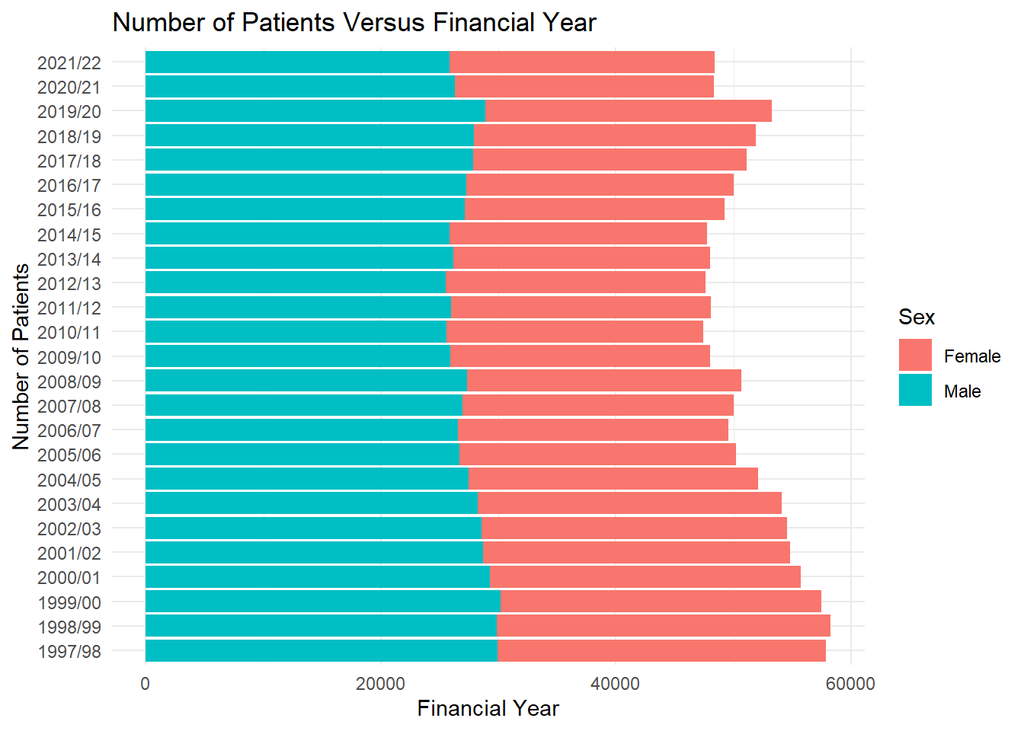

```r
#ggplot(new_df1,aes(fill=Sex,y=PatientsCount,x=AgeGroup))+geom_bar(position="dodge",stat="identity")

age.sex <- read_csv("data/mental-health-inpatient-activity-age-sex.csv")
length.of.stay <- read_csv("data/mental-health-inpatient-activity-length-of-stay.csv")
diagnosis <- read_csv("data/mental-health-inpatient-activity-diagnosis-trend.csv")
readmissions <- read_csv("data/mental-health-inpatient-activity-readmissions.csv")
#Bar chart for number of patients vs. financial year
age.sex %>%
  filter(HBR == "S92000003") %>%
  group_by(FinancialYear, Sex) %>%
  summarise(amount = sum(PatientsCount)) %>%
  ggplot(aes(y = FinancialYear,
             x = amount,
             fill = Sex)) +
  geom_col() +
  labs(x = "Financial Year",
       y = "Number of Patients",
       title = "Number of Patients Versus Financial Year")+theme_minimal()
```

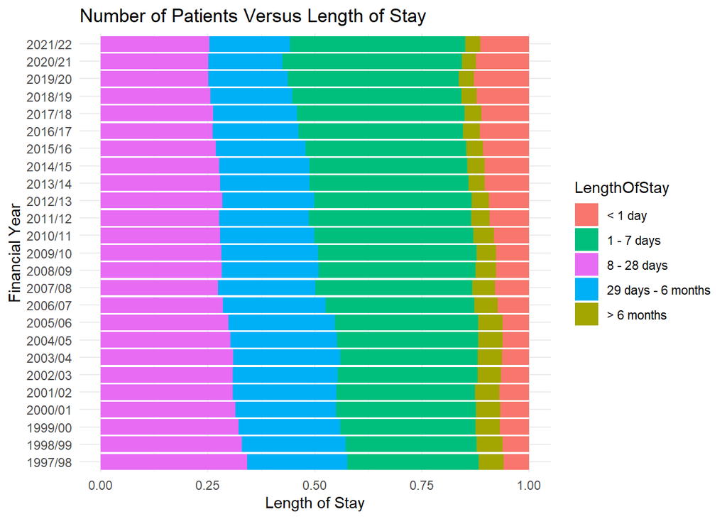

```r
#Bar chart for number of patients vs. length of stay
length.of.stay %>%
  filter(HBT == "S92000003") %>%
  group_by(FinancialYear, LengthOfStay) %>%
  summarise(amount = sum(NumberOfStays)) %>%
  ggplot(aes(y = FinancialYear,
             x = amount,
             fill = LengthOfStay)) +
  geom_col(position = "fill") +
  labs(x = "Length of Stay",
       y = "Financial Year",
       title = "Number of Patients Versus Length of Stay") +
  scale_fill_discrete(breaks = c('< 1 day',
                                 '1 - 7 days',
                                 '8 - 28 days',
                                 '29 days - 6 months',
                                 '> 6 months'))+theme_minimal()
```

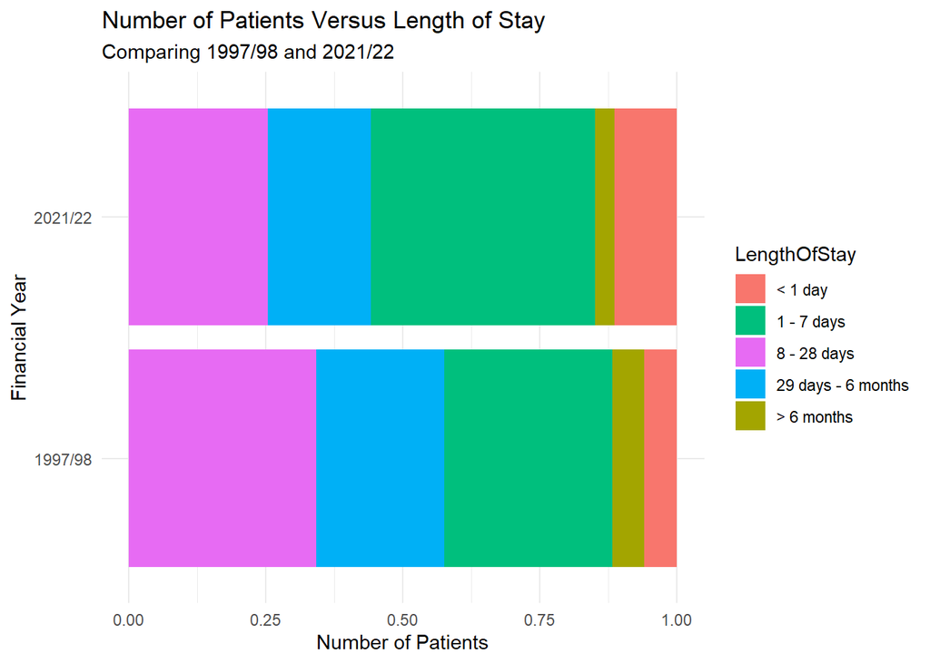

```r
#Comparing length of stay for patients in 1997/98 and 2021/22
length.of.stay %>%
  filter(HBT == "S92000003",
         FinancialYear == "1997/98" |
           FinancialYear == "2021/22") %>%
  group_by(FinancialYear, LengthOfStay) %>%
  summarise(amount = sum(NumberOfStays)) %>%
  ggplot(aes(y = FinancialYear,
             x = amount,
             fill = LengthOfStay)) +
  geom_col(position = "fill") +
  labs(x = "Number of Patients",
       y = "Financial Year",
       title = "Number of Patients Versus Length of Stay",
       subtitle = "Comparing 1997/98 and 2021/22") +
  scale_fill_discrete(breaks = c('< 1 day',
                                 '1 - 7 days',
                                 '8 - 28 days',
                                 '29 days - 6 months',
                                 '> 6 months'))+theme_minimal()
```